# Fashion MNIST Image Classifier with PyTorch

**Assignment 3 - Problem 3.** Problems 1 and 2 redone by Claude Code from one long prompt in a new session. The notebook rebuilds the *Building an Image Classifier with PyTorch* section of Chapter 10 of *Hands-On Machine Learning with Scikit-Learn and PyTorch* (Aurélien Géron, 2025) and adds a plot of the training accuracy.

Each code cell is one generated script from `scripts/`, run in order. The notebook is self-contained: the imports, device selection and the `evaluate_tm()` / `train2()` helpers from earlier in the chapter are included, so it runs from top to bottom on its own.

| Cell | Script | Step |
| --- | --- | --- |
| 1 | `01_setup.py` | Setup |
| 2 | `02_load_dataset.py` | Loading the dataset with TorchVision |
| 3 | `03_dataloaders.py` | Data loaders and sample images |
| 4 | `04_model.py` | Building the classifier |
| 5 | `05_train_functions.py` | Training and evaluation helpers |
| 6 | `06_train.py` | Training the model |
| 7 | `07_plot_training_accuracy.py` | Plotting the training accuracy (new) |
| 8 | `08_predictions.py` | Making predictions |
| 9 | `09_test_accuracy.py` | Evaluating on the test set |

## Cell 1 - Setup

*Generated script `scripts/01_setup.py`*

Import the libraries, check versions, set plot defaults and pick the fastest device (CUDA GPU, Apple-silicon MPS, or CPU).

```python
# Step 1 - Imports, version checks, plot defaults and device selection
import sys
import warnings
from packaging.version import Version

# torchvision.io's optional JPEG/PNG backend isn't used here; hide its load warning
warnings.filterwarnings("ignore", message="Failed to load image Python extension")

import numpy as np
import matplotlib.pyplot as plt
import torch
import torch.nn as nn
import torch.nn.functional as F
from torch.utils.data import DataLoader
import torchmetrics
import torchvision
import torchvision.transforms.v2 as T

assert sys.version_info >= (3, 10)
if Version(torch.__version__) < Version("2.6.0"):
    print(f"Note: PyTorch {torch.__version__} is older than the book's 2.6.0; "
          "this section runs on any PyTorch 2.x")

plt.rc("font", size=14)
plt.rc("axes", labelsize=14, titlesize=14)
plt.rc("legend", fontsize=14)
plt.rc("xtick", labelsize=10)
plt.rc("ytick", labelsize=10)

if torch.cuda.is_available():
    device = "cuda"
elif torch.backends.mps.is_available():
    device = "mps"
else:
    device = "cpu"

print(f"PyTorch {torch.__version__} | torchvision {torchvision.__version__} | "
      f"torchmetrics {torchmetrics.__version__} | device: {device}")
```

```
Note: PyTorch 2.5.1 is older than the book's 2.6.0; this section runs on any PyTorch 2.x
PyTorch 2.5.1 | torchvision 0.20.1 | torchmetrics 1.9.0 | device: mps
```

## Cell 2 - Loading the dataset with TorchVision

*Generated script `scripts/02_load_dataset.py`*

Fashion MNIST has 70,000 grayscale 28×28 images in 10 classes. Each image becomes a `float32` tensor in [0, 1]; the 60,000 training images are split 55,000 / 5,000 into training and validation sets.

```python
# Step 2 - Load Fashion MNIST with TorchVision and split train/validation
toTensor = T.Compose([T.ToImage(), T.ToDtype(torch.float32, scale=True)])

train_and_valid_data = torchvision.datasets.FashionMNIST(
    root="datasets", train=True, download=True, transform=toTensor)
test_data = torchvision.datasets.FashionMNIST(
    root="datasets", train=False, download=True, transform=toTensor)

torch.manual_seed(42)
train_data, valid_data = torch.utils.data.random_split(
    train_and_valid_data, [55_000, 5_000])

class_names = train_and_valid_data.classes
print(f"train: {len(train_data):,} | valid: {len(valid_data):,} | "
      f"test: {len(test_data):,}")
print("classes:", class_names)
```

```
train: 55,000 | valid: 5,000 | test: 10,000
classes: ['T-shirt/top', 'Trouser', 'Pullover', 'Dress', 'Coat', 'Sandal', 'Shirt', 'Sneaker', 'Bag', 'Ankle boot']
```

## Cell 3 - Data loaders and sample images

*Generated script `scripts/03_dataloaders.py`*

Batches of 32 images. Each entry is an `(image, target)` tuple and each image has shape `[channels, rows, columns]` = `[1, 28, 28]`.

```
shape: torch.Size([1, 28, 28]) | dtype: torch.float32 | label: Ankle boot
```

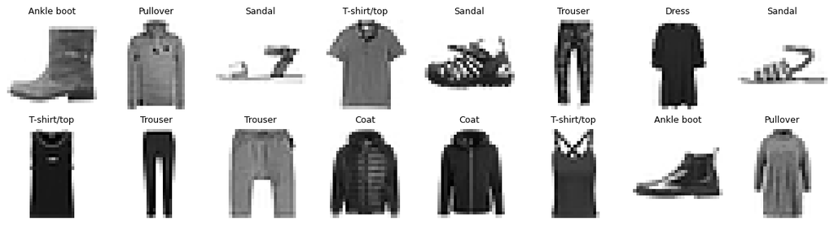

```python
# Step 3 - Data loaders and a look at the samples
torch.manual_seed(42)
train_loader = DataLoader(train_data, batch_size=32, shuffle=True)
valid_loader = DataLoader(valid_data, batch_size=32)
test_loader = DataLoader(test_data, batch_size=32)

X_sample, y_sample = train_data[0]  # each entry is an (image, target) tuple
print("shape:", X_sample.shape, "| dtype:", X_sample.dtype,
      "| label:", class_names[y_sample])

fig, axes = plt.subplots(2, 8, figsize=(12, 3.4))
for ax, idx in zip(axes.flat, range(16)):
    image, label = train_data[idx]
    ax.imshow(image.squeeze(), cmap="binary")
    ax.set_title(class_names[label], fontsize=9)
    ax.axis("off")
plt.tight_layout()
plt.show()
```

## Cell 4 - Building the classifier

*Generated script `scripts/04_model.py`*

An MLP: flatten to 784 inputs, two ReLU hidden layers (300 and 100 units), and 10 output logits. `nn.CrossEntropyLoss` applies the softmax itself.

```python
# Step 4 - Build the MLP image classifier
class ImageClassifier(nn.Module):
    def __init__(self, n_inputs, n_hidden1, n_hidden2, n_classes):
        super().__init__()
        self.mlp = nn.Sequential(
            nn.Flatten(),
            nn.Linear(n_inputs, n_hidden1),
            nn.ReLU(),
            nn.Linear(n_hidden1, n_hidden2),
            nn.ReLU(),
            nn.Linear(n_hidden2, n_classes)
        )

    def forward(self, X):
        return self.mlp(X)

torch.manual_seed(42)
model = ImageClassifier(n_inputs=1 * 28 * 28, n_hidden1=300, n_hidden2=100,
                        n_classes=10).to(device)
xentropy = nn.CrossEntropyLoss()

print(model)
print("trainable parameters:", sum(p.numel() for p in model.parameters()))
```

```
ImageClassifier(
  (mlp): Sequential(
    (0): Flatten(start_dim=1, end_dim=-1)
    (1): Linear(in_features=784, out_features=300, bias=True)
    (2): ReLU()
    (3): Linear(in_features=300, out_features=100, bias=True)
    (4): ReLU()
    (5): Linear(in_features=100, out_features=10, bias=True)
  )
)
trainable parameters: 266610
```

## Cell 5 - Training and evaluation helpers

*Generated script `scripts/05_train_functions.py`*

`evaluate_tm()` computes a `torchmetrics` metric over a data loader; `train2()` runs the training loop and returns the per-epoch loss and metrics. Both come from earlier in Chapter 10.

```python
# Step 5 - Evaluation and training helpers (defined earlier in Chapter 10)
def evaluate_tm(model, data_loader, metric):
    model.eval()
    metric.reset()
    with torch.no_grad():
        for X_batch, y_batch in data_loader:
            X_batch, y_batch = X_batch.to(device), y_batch.to(device)
            y_pred = model(X_batch)
            metric.update(y_pred, y_batch)
    return metric.compute()

def train2(model, optimizer, criterion, metric, train_loader, valid_loader,
           n_epochs):
    history = {"train_losses": [], "train_metrics": [], "valid_metrics": []}
    for epoch in range(n_epochs):
        total_loss = 0.
        metric.reset()
        for X_batch, y_batch in train_loader:
            model.train()
            X_batch, y_batch = X_batch.to(device), y_batch.to(device)
            y_pred = model(X_batch)
            loss = criterion(y_pred, y_batch)
            total_loss += loss.item()
            loss.backward()
            optimizer.step()
            optimizer.zero_grad()
            metric.update(y_pred, y_batch)
        mean_loss = total_loss / len(train_loader)
        history["train_losses"].append(mean_loss)
        history["train_metrics"].append(metric.compute().item())
        history["valid_metrics"].append(
            evaluate_tm(model, valid_loader, metric).item())
        print(f"Epoch {epoch + 1}/{n_epochs}, "
              f"train loss: {history['train_losses'][-1]:.4f}, "
              f"train metric: {history['train_metrics'][-1]:.4f}, "
              f"valid metric: {history['valid_metrics'][-1]:.4f}")
    return history
```

## Cell 6 - Training the model

*Generated script `scripts/06_train.py`*

20 epochs of SGD (learning rate 0.1), tracking multiclass accuracy. The book discards `train2()`'s return value; here it is kept as `history` for plotting.

```python
# Step 6 - Train for 20 epochs with SGD, keeping the history for plotting
n_epochs = 20
optimizer = torch.optim.SGD(model.parameters(), lr=0.1)
accuracy = torchmetrics.Accuracy(task="multiclass", num_classes=10).to(device)
history = train2(model, optimizer, xentropy, accuracy, train_loader,
                 valid_loader, n_epochs)
```

[output not shown]

## Cell 7 - Plotting the training accuracy (new)

*Generated script `scripts/07_plot_training_accuracy.py`*

Not in the book. Training accuracy is averaged while the weights change during an epoch, so it is plotted half an epoch earlier. Validation accuracy and training loss are shown for comparison.

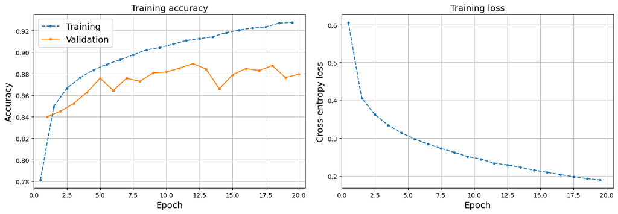

```
Final training accuracy:   0.9276
Final validation accuracy: 0.8796 (best 0.8894 at epoch 12)
```

```python
# Step 7 (new) - Plot the training accuracy (with validation accuracy and loss)
epochs = np.arange(1, n_epochs + 1)
fig, (ax_acc, ax_loss) = plt.subplots(1, 2, figsize=(14, 5))

# Training metrics are averaged during each epoch, so shift them back half an epoch
ax_acc.plot(epochs - 0.5, history["train_metrics"], ".--", label="Training")
ax_acc.plot(epochs, history["valid_metrics"], ".-", label="Validation")
ax_acc.set_xlabel("Epoch")
ax_acc.set_ylabel("Accuracy")
ax_acc.set_title("Training accuracy")
ax_acc.set_xlim(0, n_epochs + 0.5)
ax_acc.grid()
ax_acc.legend()

ax_loss.plot(epochs - 0.5, history["train_losses"], ".--", color="C0")
ax_loss.set_xlabel("Epoch")
ax_loss.set_ylabel("Cross-entropy loss")
ax_loss.set_title("Training loss")
ax_loss.set_xlim(0, n_epochs + 0.5)
ax_loss.grid()

plt.tight_layout()
plt.show()

best = int(np.argmax(history["valid_metrics"]))
print(f"Final training accuracy:   {history['train_metrics'][-1]:.4f}")
print(f"Final validation accuracy: {history['valid_metrics'][-1]:.4f} "
      f"(best {history['valid_metrics'][best]:.4f} at epoch {best + 1})")
```

## Cell 8 - Making predictions

*Generated script `scripts/08_predictions.py`*

Classify three validation images: the predicted class is the largest logit, and the softmax of the logits gives the class probabilities.

```python
# Step 8 - Predict classes and probabilities for three validation images
model.eval()
X_new, y_new = next(iter(valid_loader))
X_new = X_new[:3].to(device)
with torch.no_grad():
    y_pred_logits = model(X_new)
y_pred = y_pred_logits.argmax(dim=1)  # index of the largest logit

print("predicted:", [class_names[i] for i in y_pred])
print("actual:   ", [class_names[i] for i in y_new[:3]])

y_proba = F.softmax(y_pred_logits, dim=1).cpu()
print("\nclass probabilities:\n", y_proba.round(decimals=3))

y_top4_values, y_top4_indices = torch.topk(y_pred_logits, k=4, dim=1)
y_top4_probas = F.softmax(y_top4_values, dim=1).cpu()
print("\ntop-4 classes (probabilities renormalized over those 4):")
for i in range(3):
    print(f"  image {i}: " + ", ".join(
        f"{class_names[c]} {p:.3f}"
        for c, p in zip(y_top4_indices[i].tolist(), y_top4_probas[i].tolist())))
```

```
predicted: ['Sneaker', 'Coat', 'Pullover']
actual:    ['Sneaker', 'Coat', 'Pullover']

class probabilities:
 tensor([[0.0000, 0.0000, 0.0000, 0.0000, 0.0000, 0.0000, 0.0000, 0.8540, 0.0000,
         0.1450],
        [0.0000, 0.0000, 0.0050, 0.0000, 0.9940, 0.0000, 0.0010, 0.0000, 0.0000,
         0.0000],
        [0.0020, 0.0000, 0.6470, 0.0000, 0.1150, 0.0000, 0.2360, 0.0000, 0.0000,
         0.0000]])
```

```
top-4 classes (probabilities renormalized over those 4):
  image 0: Sneaker 0.854, Ankle boot 0.145, Sandal 0.000, Bag 0.000
  image 1: Coat 0.994, Pullover 0.005, Shirt 0.001, T-shirt/top 0.000
  image 2: Pullover 0.647, Shirt 0.236, Coat 0.115, T-shirt/top 0.002
```

## Cell 9 - Evaluating on the test set

*Generated script `scripts/09_test_accuracy.py`*

How well the model generalizes to the 10,000 held-out test images.

```python
# Step 9 - Accuracy on the 10,000-image test set
test_accuracy = evaluate_tm(model, test_loader, accuracy).item()
print(f"Test accuracy: {test_accuracy:.4f}")
```

```
Test accuracy: 0.8832
```